# IE582 HW_2

Abdulsamed Kağıt

08/12/2020

## Task 1

Read the data and visualize one instance (all axes) from each class and try to relate the shape (time series) you see with the gestures shown in Figure 1. A 3D scatter plot would be interesting. Note that this is an acceleration information. You can transform this information to a velocity vector by computing the cumulative sum of acceleration over time.

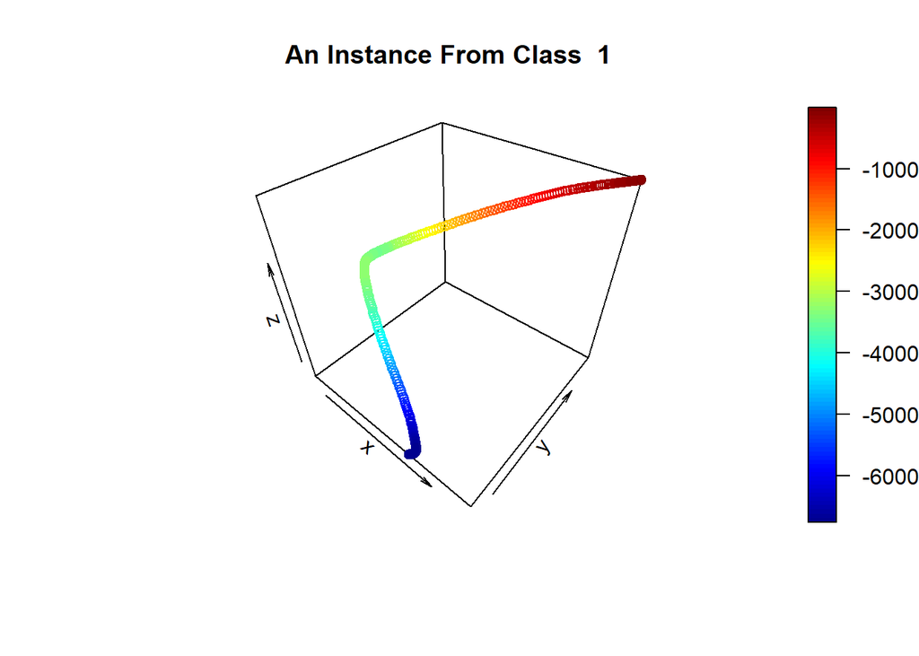

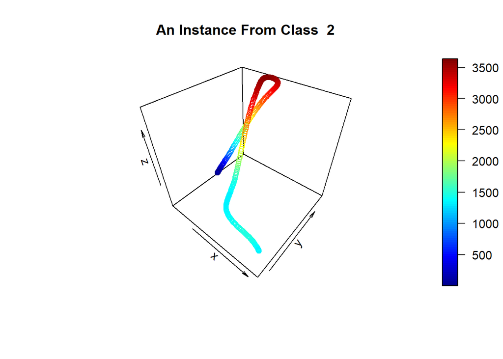

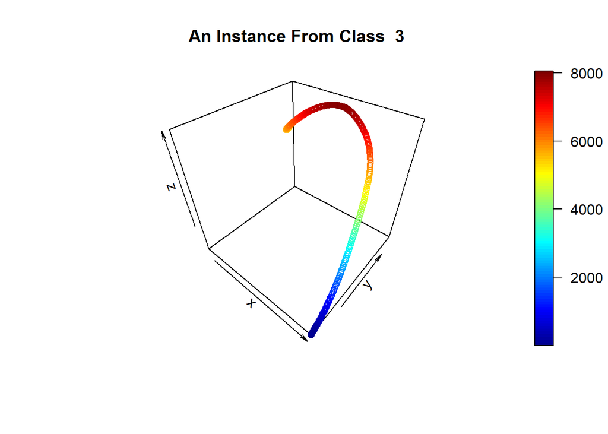

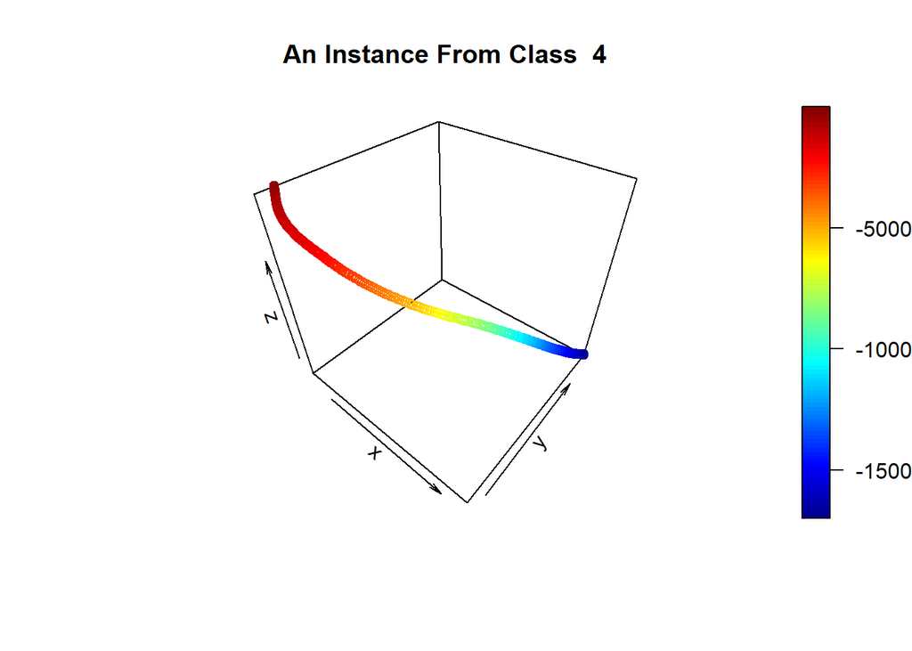

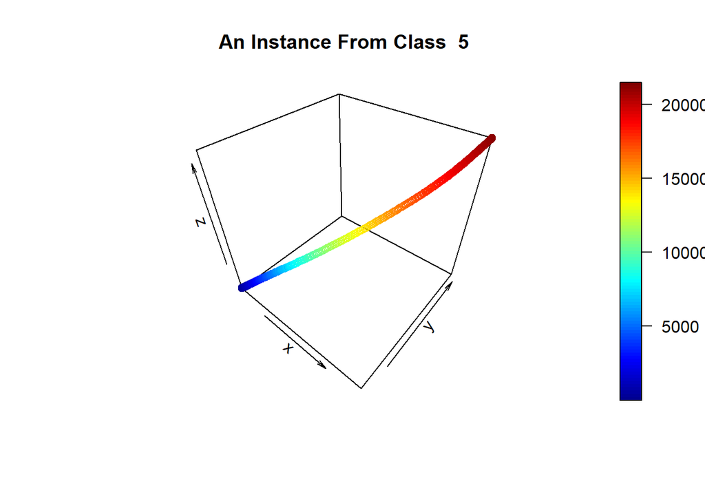

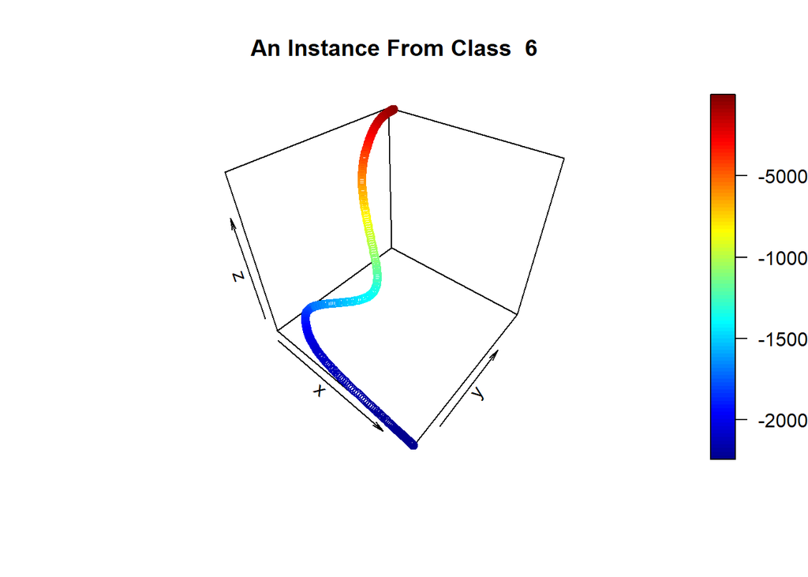

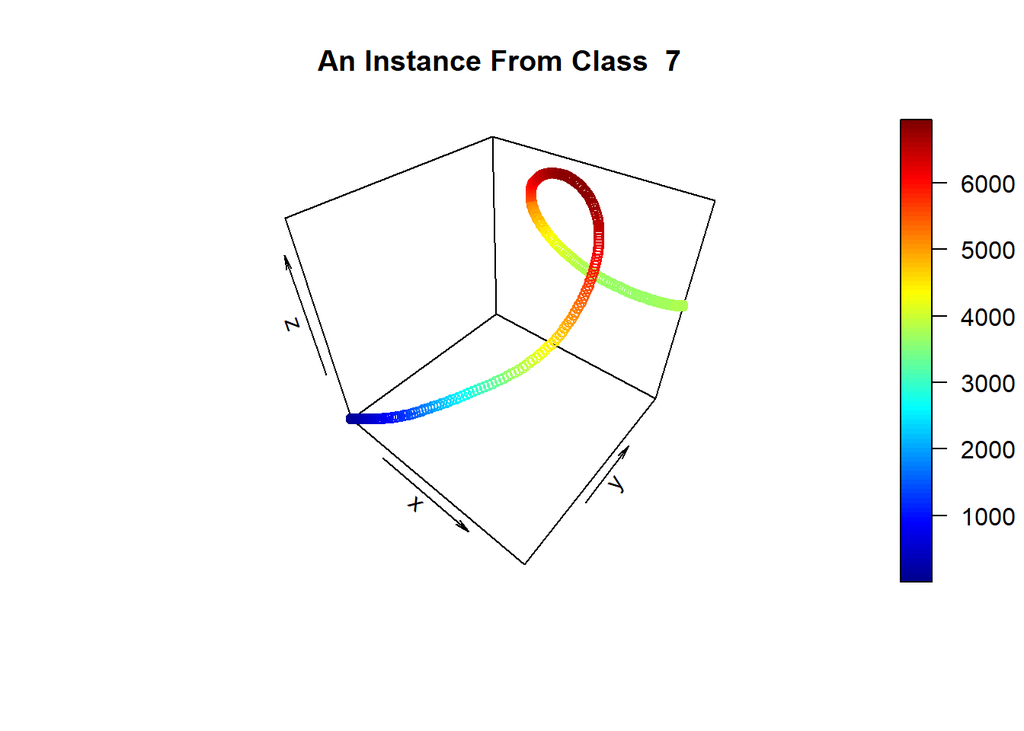

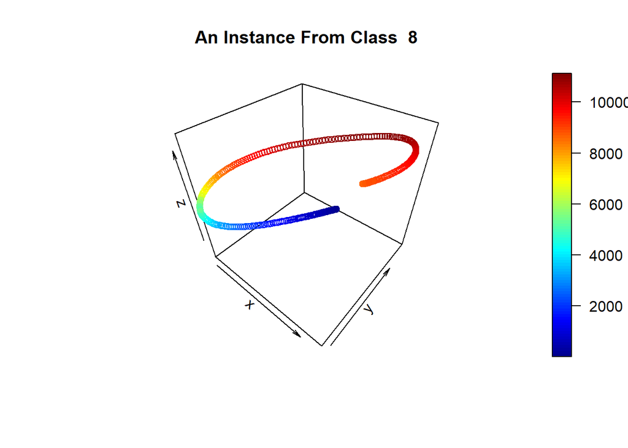

```r
#Libraries

library(ggplot2)
library(dplyr)
library(yardstick)
library(broom)
library(purrr)
library(data.table)
library(stringr)
library(tidyr)
library(ggfortify)
library(tidyverse)
library(plot3D)

#Data Reading

train_x <- fread("C:/Users/Abdulsamed/Desktop/IE582/uWaveGestureLibrary_X_TRAIN")
train_y <- fread("C:/Users/Abdulsamed/Desktop/IE582/uWaveGestureLibrary_Y_TRAIN")
train_z <- fread("C:/Users/Abdulsamed/Desktop/IE582/uWaveGestureLibrary_Z_TRAIN")

#Adjust Column Names

colnames(train_x)[1] = "class"
newnames <- paste("t",1: (ncol(train_x)-1), sep = "")
colnames(train_x)[2:ncol(train_x)] = newnames

colnames(train_y)[1] = "class"
newnames <- paste("t",1: (ncol(train_y)-1), sep = "")
colnames(train_y)[2:ncol(train_y)] = newnames

colnames(train_z)[1] = "class"
newnames <- paste("t",1: (ncol(train_z)-1), sep = "")
colnames(train_z)[2:ncol(train_z)] = newnames

#Calculate Velocity From Acceleration

mySum = t(apply(train_x[,-1], 1, cumsum))
train_x_velo <- cbind(train_x[,1],mySum)

mySum = t(apply(train_y[,-1], 1, cumsum))
train_y_velo <- cbind(train_y[,1],mySum)

mySum = t(apply(train_z[,-1], 1, cumsum))
train_z_velo <- cbind(train_z[,1],mySum)

#Calculate Position From Velocity

mySum = t(apply(train_x_velo[,-1], 1, cumsum))
train_x_pos <- cbind(train_x_velo[,1],mySum)

mySum = t(apply(train_y_velo[,-1], 1, cumsum))
train_y_pos <- cbind(train_y_velo[,1],mySum)

mySum = t(apply(train_z_velo[,-1], 1, cumsum))
train_z_pos <- cbind(train_z_velo[,1],mySum)

rm(mySum)

#Data Visualization

instances <- list()
for(i in 1:8)
{
instances=append(instances,list(cbind(t((train_x_pos%>%filter(class==i))[1,-1]),t((train_y_pos%>%filter(class==i))[1,-1]),t((train_z_pos%>%filter(class==i))[1,-1]))))
}


for(i in 1:8)
{
  a <- as.data.frame(unlist(instances[[i]]))
  scatter3D(x=a$V1,y=a$V2,z=a$V3, main=paste("An Instance From Class ", i))
  rm(a)
  }
```

3D scatter plots roughly look like the figures provided in the description.

## Task 2

The data is provided as a regular data matrix (i.e. each row represents an instance and columns represent the time index of the observations). On the other hand, this is an example of multivariate time series where we have X, Y and Z variables. Our aim is to reduce this multivariate time series to a univariate one with a dimensionality reduction approach. One way to achieve this task is to transform your data into the long format. Suppose we decide to reduce the data from 3D (i.e. X, Y and Z features) to 1D using PCA. Relevant columns for PCA is X, Y and Z. Apply PCA to the whole data (regardless of the time series id or class) and report PCA results. Select 2 random time series from each class and visualize the reduced dimensions as time series in a single plot to see if classes can be separated in the reduced dimensions. Visual inspection is enough.

```r
#Transform to Longer Format

train_x_adj <- cbind(time_series_id=1:nrow(train_x), train_x)
train_y_adj <- cbind(time_series_id=1:nrow(train_y), train_y)
train_z_adj <- cbind(time_series_id=1:nrow(train_z), train_z)

train_x_adj_long<-pivot_longer(train_x_adj,-contains("s"),names_to="time_index",values_to="x",names_prefix ="t",names_transform=list("time_index"=as.integer))
train_y_adj_long<-pivot_longer(train_y_adj,-contains("s"),names_to="time_index",values_to="y",names_prefix ="t",names_transform=list("time_index"=as.integer))
train_z_adj_long<-pivot_longer(train_z_adj,-contains("s"),names_to="time_index",values_to="z",names_prefix ="t",names_transform=list("time_index"=as.integer))

train_xyz_long <- inner_join(train_x_adj_long,train_y_adj_long,by=c("time_series_id","class","time_index"))
train_xyz_long <- inner_join(train_xyz_long,train_z_adj_long,by=c("time_series_id","class","time_index"))
train_xyz_long
```

```
## # A tibble: 282,240 x 6
##    time_series_id class time_index      x     y     z
##             <int> <dbl>      <int>  <dbl> <dbl> <dbl>
##  1              1     6          1 -0.304 -2.12 -1.53
##  2              1     6          2 -0.304 -2.12 -1.53
##  3              1     6          3 -0.304 -2.12 -1.53
##  4              1     6          4 -0.304 -2.12 -1.53
##  5              1     6          5 -0.304 -2.12 -1.53
##  6              1     6          6 -0.304 -2.12 -1.53
##  7              1     6          7 -0.304 -2.12 -1.53
##  8              1     6          8 -0.304 -2.12 -1.53
##  9              1     6          9 -0.304 -2.12 -1.53
## 10              1     6         10 -0.304 -2.12 -1.53
## # ... with 282,230 more rows
```

```r
#PCA

pca_xyz <- prcomp(train_xyz_long%>%select(x,y,z), scale=TRUE)
tidy(pca_xyz,"pcs") #0.49 of the variance kept
```

```
## # A tibble: 3 x 4
##      PC std.dev percent cumulative
##   <dbl>   <dbl>   <dbl>      <dbl>
## 1     1   1.21    0.491      0.491
## 2     2   1.02    0.347      0.837
## 3     3   0.699   0.163      1
```

```r
pca_xyz$rotation
```

```
##         PC1         PC2        PC3
## x 0.4268455 -0.77631140 -0.4638357
## y 0.7212650 -0.01714887  0.6924469
## z 0.5455087  0.63011628 -0.5526063
```

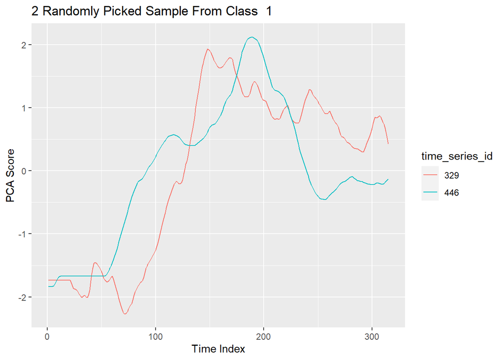

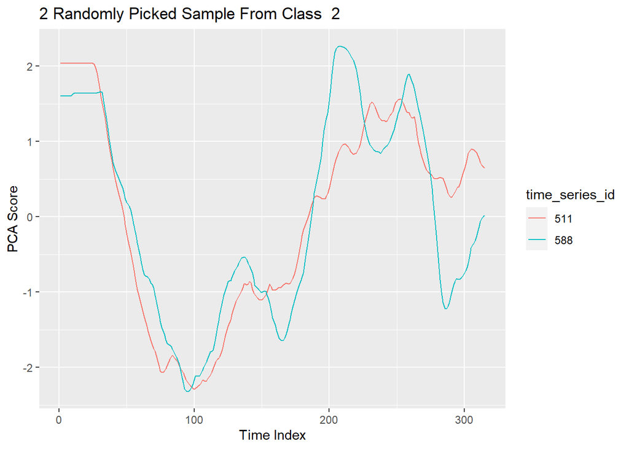

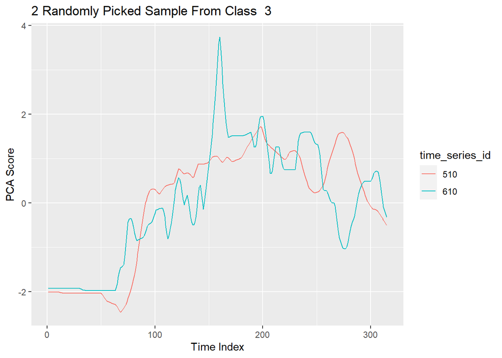

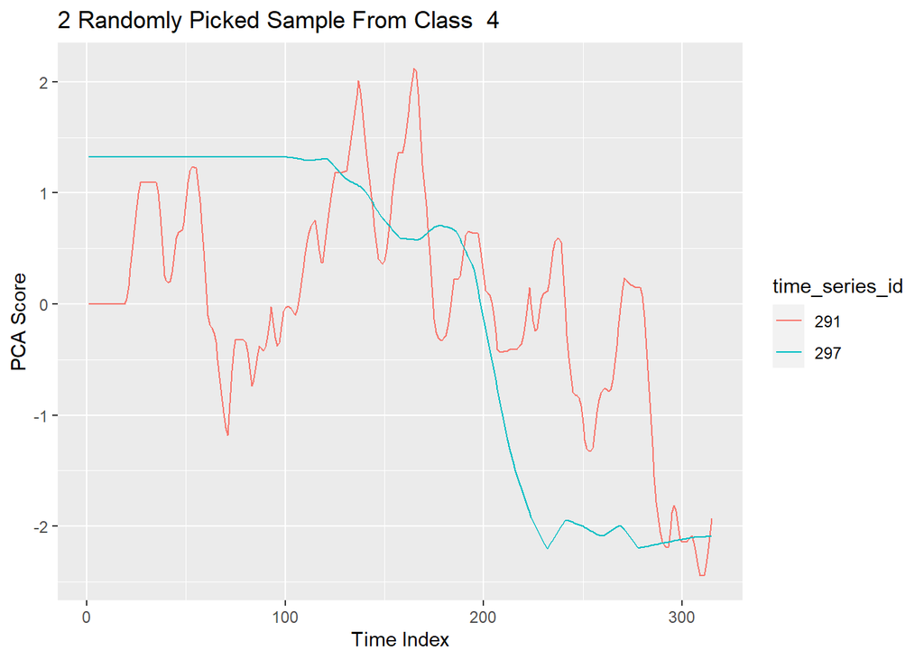

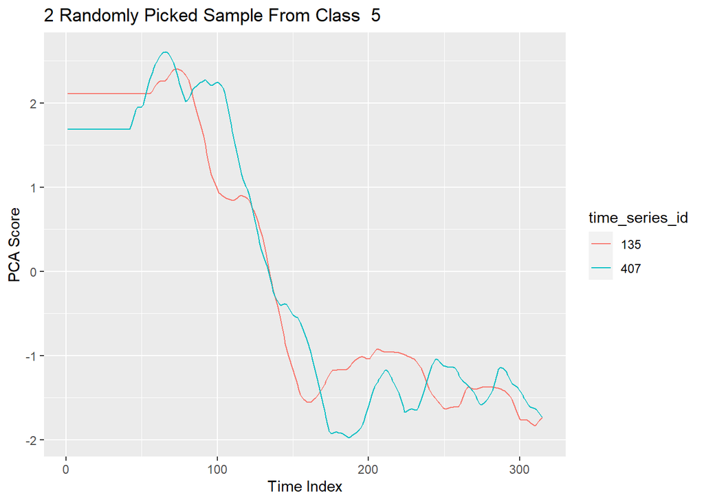

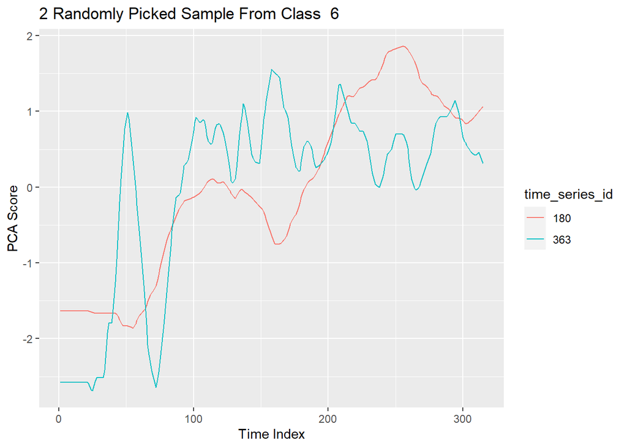

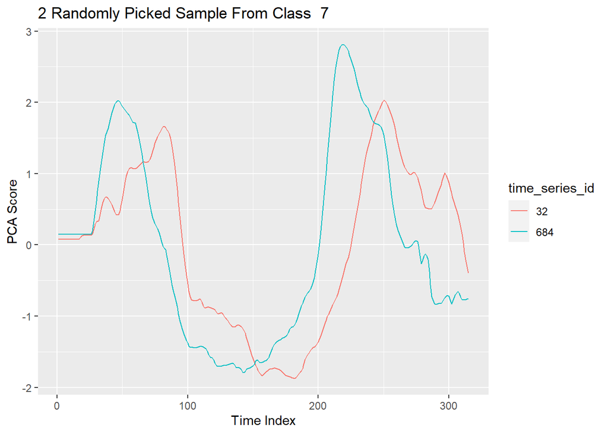

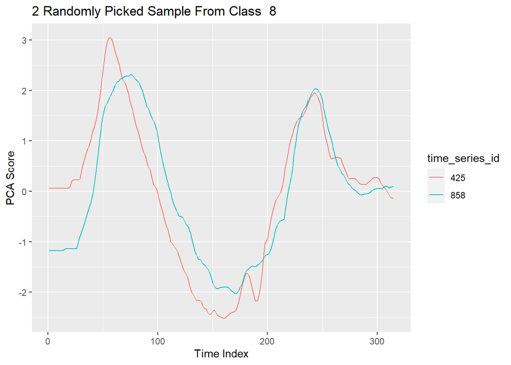

```r
train_xyz_long_pca <- cbind(train_xyz_long,score=(pca_xyz$x)[,1]) %>% select(-x,-y,-z)
set.seed(130)
for(i in 1:8)
{
  chosen <- train_xyz_long_pca %>% filter(class == i)
  chosen <- unique(chosen$time_series_id) %>% sample(size=2)
  chosen1 <- train_xyz_long_pca %>% filter(time_series_id == chosen[1])
  chosen2 <- train_xyz_long_pca %>% filter(time_series_id == chosen[2])
  chosen <- bind_rows(chosen1,chosen2)
  chosen$time_series_id = as.character(chosen$time_series_id)
  print(ggplot(chosen,aes(x=time_index,y=score,color=time_series_id))+geom_line()+labs(title=paste("2 Randomly Picked Sample From Class ",i),x="Time Index",y="PCA Score"))
  rm(chosen,chosen1,chosen2)
  }
```

49% of the variance is explained by PC1. PC1 = c(x=0.4268455, y=0.7212650, z=0.5455087). 2 instances are sampled from each class and concluded that samples from same classes generally resemble each other. However it may not be possible to differentiate classes judging by PC1 only. Class 7 and Class 8 are good examples for that. Graph of both samples from Class 7 and Class 8 resemble “M” shape although they are from different classes.

## Task 3

It is also interesting to compare the first principal component when PCA is applied on the data from each gesture. In other words, you are expected to filter the data for each class and apply PCA (you will perform PCA eight times). Report PCA results (components, variance covered by each component). Is there any interesting observation on the first component of the PCA results applied to the data from each class? Are the first components similar? Comment on your findings.

```r
#PCA for each class

class_pca <- train_xyz_long %>% group_by(class) %>% arrange(class) %>% nest() %>%
 mutate(pca=purrr::map(data,function(d) prcomp(d%>%select(x,y,z))), rotation_pca= purrr::map(pca,function(d) tidy(d,matrix="rotation")%>%filter(PC==1)),
    eigenvalues_pca = purrr::map(pca, function(d) tidy(d,matrix="eigenvalues")%>%filter(PC==1) %>% select(-PC))) %>%
      unnest(c(rotation_pca,eigenvalues_pca)) %>% select(class,column, value, cumulative,PC) %>% pivot_wider(names_from = column, values_from=value)

class_pca
```

```
## # A tibble: 8 x 6
## # Groups:   class [8]
##   class cumulative    PC      x      y      z
##   <dbl>      <dbl> <dbl>  <dbl>  <dbl>  <dbl>
## 1     1      0.463     1  0.357  0.691  0.629
## 2     2      0.513     1 -0.455 -0.685 -0.569
## 3     3      0.541     1 -0.675 -0.531  0.513
## 4     4      0.550     1 -0.681 -0.634  0.367
## 5     5      0.647     1 -0.399 -0.643 -0.654
## 6     6      0.572     1  0.206 -0.680 -0.704
## 7     7      0.519     1 -0.229 -0.715 -0.661
## 8     8      0.613     1  0.574  0.693  0.436
```

PCA results for each class are available in the data frame above. Negative PC1 of class 1 is similar to PC1 of class 5. Other PC1s seem to be more or less distinct. From the table we can see that only 0.46 of the variance of class 1 data is explained by PC1, which is lower than that of PC1 of all classes. For other classes however, applying PCA for each class separately increased the proportion of variance explained by PC1.

## Task 4

Suppose, our aim now is to visualize the time series in reduced dimensions for classification purposes. Assume that we compute the distance between the time series for each axis using the original representation (i.e. a row represents individual time series, column is the time index and entries are the observations) over each axis and sum them up to obtain a final distance measure. You are expected to obtain a symmetric distance matrix. Let’s apply multidimensional scaling to this distance matrix to represent each time series on a 2-dimensional feature space. Visualize the observations using the reduced features and color-code the points with the class information. Comment on your findings.

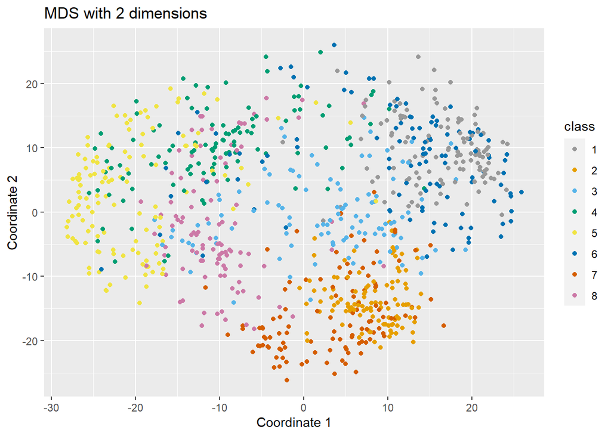

```r
#MDS

mds_matris<- inner_join(train_x_adj,train_y_adj,by=c("class","time_series_id"),suffix=c("_x","_y"))
mds_matris<- inner_join(mds_matris,train_z_adj,by=c("class","time_series_id"))

distance_matrix <- dist(mds_matris%>%select(-class,-time_series_id))

mds_fit <- cmdscale(distance_matrix,eig=TRUE, k=2)

x <- mds_fit$points[,1]
y <- mds_fit$points[,2]

mds_applied_ts <- cbind(x,y,mds_matris[,1:2])
mds_applied_ts$class = as.character(mds_applied_ts$class)
mycolor <- c("#999999", "#E69F00", "#56B4E9", "#009E73","#F0E442", "#0072B2", "#D55E00", "#CC79A7")

ggplot(mds_applied_ts,aes(x=x,y=y,color=class))+geom_point() + scale_color_manual(values=mycolor) +
  labs(title = "MDS with 2 dimensions",x="Coordinate 1", y="Coordinate 2")
```

Observations from the same classes are tend to cluster mostly. It can be seen that class 2 and class 7, class 7 and class 8, class 4 and class 5 are kind of adjacent. Class 3 is wide-spread. Class 1 and Class 6 seems to be intertwined. MDS method seems not to be useful for classifying class 1 and 6, but partial success can be achieved for other classes.